# Child Care Inspection in New York City

## 1 Introduction

Child Care inspection in New York City is a significant issue highlighted in the recent years (2018-2021) where child care centers underwent several rounds of inspection for its legitimacy. This dataset contains a record of all investigations conducted and any related violations at active, city-regulated, center-based child care programs and summer camps over that period of time. These violations are pre-adjudged and such violations are subjected to penalties (fines) and they are submitted to the New York City Office of Administrative Trials and Hearing where they are adjudged as either sustained/upheld or excused. The dataset in addition contains more information on the programs, including license information where each row is a single violation cited during the inspection.

This project aims to learn how the childcare inspection has helped the centers over the period to curb the violation rate by taking into consideration the following factors like public health hazard violation, critical violation etc. Therefore, our team will be focusing on the following SMART questions in this project:

1. To discover the distribution of Centers, Borough and Program Type
2. What is the percent of violations reported in each category in all the childcare centers?
3. Which borough has improved over the period (2018-2021)?

Next, we will use exploratory data analysis(EDA), statistical testing and model building to solve our smart questions.

## 2 EDA

### 2.1 Preparation for EDA

```r
# Import the data, call it `childcare_orig.
loadPkg("readr")
childcare_orig <- data.frame(read_csv("DOHMH_Childcare_Center_Inspections.csv"))
str(childcare_orig)
```

```
## 'data.frame':    37312 obs. of  34 variables:
##  $ Center.Name                                : chr  "GKO GROUP INCORPORATED" "RALPH HIRSCHKORN CHILD CARE CENTER" "STATEN ISLAND SKATING PAVILION, INC." "LUTHERAN SOCIAL SERVICES OF METROPOLITAN NEW YORK" ...
##  $ Legal.Name                                 : chr  "GKO GROUP INCORPORATED" "HEBREW KINDERGARTEN & INFANTS HOME,INC" "STATEN ISLAND SKATING PAVILION, INC" "LUTHERAN SOCIAL SERVICES OF METROPOLITAN NEW YORK, INC." ...
##  $ Building                                   : chr  "4020" "310" "3080" "2125" ...
##  $ Street                                     : chr  "EAST TREMONT AVENUE" "BEACH 20 STREET" "ARTHUR KILL ROAD" "WATSON AVENUE" ...
##  $ Borough                                    : chr  "BRONX" "QUEENS" "STATEN ISLAND" "BRONX" ...
##  $ ZipCode                                    : num  10465 11691 10309 10472 11354 ...
##  $ Phone                                      : chr  "718-239-5275" "718-327-1141" "718-948-4800" "718-943-0580" ...
##  $ Permit.Number                              : num  6790 2319 94157 28757 6902 ...
##  $ Permit.Expiration                          : chr  "08/31/2022" "11/27/2021" "07/31/2021" "12/06/2020" ...
##  $ Status                                     : chr  "Permitted" "Permitted" "Permitted" "Expired-In Renewal" ...
##  $ Age.Range                                  : chr  "2 YEARS - 5 YEARS" NA "2 YEARS - 5 YEARS" "2 YEARS - 5 YEARS" ...
##  $ Maximum.Capacity                           : num  190 90 22 115 254 79 39 57 72 132 ...
##  $ Day.Care.ID                                : chr  "DC14269" "DC2326" "DC32746" "DC22393" ...
##  $ Program.Type                               : chr  "PRESCHOOL" "PRESCHOOL" "PRESCHOOL" "PRESCHOOL" ...
```

[output cut: 20 more lines]

```r
# nrow(childcare_orig)
```

The above is our original dataset. There are 37312 observations and 34 variables. We can see that some data here is meaningless and unneeded such as ZipCode, Building, Street, Phone, Permit.Number, Day.Care.ID, Building.Identification.Number, etc. So we have to clean up the data before doing analysis.

```r
# Remove redundant duplicated entries, drop unwanted variables, call it childcare
childcare <- childcare_orig[!duplicated(childcare_orig), ] %>%
             subset(select = -c(ZipCode, Building, Street, Phone, Permit.Number, Day.Care.ID, Building.Identification.Number, Actual, URL, Regulation.Summary, Health.Code.Sub.Section, Inspection.Summary.Result))
childcare$Program.Type <- toupper(childcare$Program.Type)
str(childcare)
```

```
## 'data.frame':    29284 obs. of  22 variables:
##  $ Center.Name                                : chr  "GKO GROUP INCORPORATED" "RALPH HIRSCHKORN CHILD CARE CENTER" "STATEN ISLAND SKATING PAVILION, INC." "LUTHERAN SOCIAL SERVICES OF METROPOLITAN NEW YORK" ...
##  $ Legal.Name                                 : chr  "GKO GROUP INCORPORATED" "HEBREW KINDERGARTEN & INFANTS HOME,INC" "STATEN ISLAND SKATING PAVILION, INC" "LUTHERAN SOCIAL SERVICES OF METROPOLITAN NEW YORK, INC." ...
##  $ Borough                                    : chr  "BRONX" "QUEENS" "STATEN ISLAND" "BRONX" ...
##  $ Permit.Expiration                          : chr  "08/31/2022" "11/27/2021" "07/31/2021" "12/06/2020" ...
##  $ Status                                     : chr  "Permitted" "Permitted" "Permitted" "Expired-In Renewal" ...
##  $ Age.Range                                  : chr  "2 YEARS - 5 YEARS" NA "2 YEARS - 5 YEARS" "2 YEARS - 5 YEARS" ...
##  $ Maximum.Capacity                           : num  190 90 22 115 254 79 39 57 72 132 ...
##  $ Program.Type                               : chr  "PRESCHOOL" "PRESCHOOL" "PRESCHOOL" "PRESCHOOL" ...
##  $ Facility.Type                              : chr  "GDC" "GDC" "GDC" "GDC" ...
##  $ Child.Care.Type                            : chr  "Child Care - Pre School" "Child Care - Pre School" "Child Care - Pre School" "Child Care - Pre School" ...
##  $ Date.Permitted                             : chr  "06/02/2004" "08/07/1980" "07/31/2015" "12/06/2012" ...
##  $ Violation.Rate.Percent                     : num  66.7 25 0 66.7 16.7 ...
##  $ Average.Violation.Rate.Percent             : num  24.9 24.9 24.9 24.9 24.9 ...
##  $ Total.Educational.Workers                  : num  26 17 3 14 9 5 7 8 10 10 ...
##  $ Average.Total.Educational.Workers          : num  10.1 10.1 10.1 10.1 10.1 ...
##  $ Public.Health.Hazard.Violation.Rate        : num  33.3 0 0 33.3 16.7 ...
##  $ Average.Public.Health.Hazard.Violation.Rate: num  9.31 9.31 9.31 9.31 9.31 ...
##  $ Critical.Violation.Rate                    : num  66.7 25 0 66.7 16.7 ...
##  $ Average.Critical.Violation.Rate            : num  22.2 22.2 22.2 22.2 22.2 ...
##  $ Inspection.Date                            : chr  "03/13/2018" "06/25/2018" "01/29/2020" "10/08/2019" ...
##  $ Violation.Category                         : chr  NA "CRITICAL" NA "GENERAL" ...
##  $ Violation.Status                           : chr  "N/A" "CORRECTED" "N/A" "CORRECTED" ...
```

```r
# nrow(childcare)
```

We removed redundant duplicated entries and dropped unwanted variables, then we got a new dataset. We called it *childcare*. We wil use it for later analysis. Now, there are only 29284 observations and 22 variables. We can see there were quite a lot of human errors in the original dataset (over 8000 unnecessary duplicate entries).

```r
# Select only the unique rows based on Names, Call it Centers
Centers <- childcare[!duplicated(childcare$Center.Name), ]
str(Centers)
```

```
## 'data.frame':    2211 obs. of  22 variables:
##  $ Center.Name                                : chr  "GKO GROUP INCORPORATED" "RALPH HIRSCHKORN CHILD CARE CENTER" "STATEN ISLAND SKATING PAVILION, INC." "LUTHERAN SOCIAL SERVICES OF METROPOLITAN NEW YORK" ...
##  $ Legal.Name                                 : chr  "GKO GROUP INCORPORATED" "HEBREW KINDERGARTEN & INFANTS HOME,INC" "STATEN ISLAND SKATING PAVILION, INC" "LUTHERAN SOCIAL SERVICES OF METROPOLITAN NEW YORK, INC." ...
##  $ Borough                                    : chr  "BRONX" "QUEENS" "STATEN ISLAND" "BRONX" ...
##  $ Permit.Expiration                          : chr  "08/31/2022" "11/27/2021" "07/31/2021" "12/06/2020" ...
##  $ Status                                     : chr  "Permitted" "Permitted" "Permitted" "Expired-In Renewal" ...
##  $ Age.Range                                  : chr  "2 YEARS - 5 YEARS" NA "2 YEARS - 5 YEARS" "2 YEARS - 5 YEARS" ...
##  $ Maximum.Capacity                           : num  190 90 22 115 254 79 39 57 72 132 ...
##  $ Program.Type                               : chr  "PRESCHOOL" "PRESCHOOL" "PRESCHOOL" "PRESCHOOL" ...
##  $ Facility.Type                              : chr  "GDC" "GDC" "GDC" "GDC" ...
##  $ Child.Care.Type                            : chr  "Child Care - Pre School" "Child Care - Pre School" "Child Care - Pre School" "Child Care - Pre School" ...
##  $ Date.Permitted                             : chr  "06/02/2004" "08/07/1980" "07/31/2015" "12/06/2012" ...
##  $ Violation.Rate.Percent                     : num  66.7 25 0 66.7 16.7 ...
##  $ Average.Violation.Rate.Percent             : num  24.9 24.9 24.9 24.9 24.9 ...
##  $ Total.Educational.Workers                  : num  26 17 3 14 9 5 7 8 10 10 ...
##  $ Average.Total.Educational.Workers          : num  10.1 10.1 10.1 10.1 10.1 ...
##  $ Public.Health.Hazard.Violation.Rate        : num  33.3 0 0 33.3 16.7 ...
##  $ Average.Public.Health.Hazard.Violation.Rate: num  9.31 9.31 9.31 9.31 9.31 ...
##  $ Critical.Violation.Rate                    : num  66.7 25 0 66.7 16.7 ...
##  $ Average.Critical.Violation.Rate            : num  22.2 22.2 22.2 22.2 22.2 ...
##  $ Inspection.Date                            : chr  "03/13/2018" "06/25/2018" "01/29/2020" "10/08/2019" ...
##  $ Violation.Category                         : chr  NA "CRITICAL" NA "GENERAL" ...
##  $ Violation.Status                           : chr  "N/A" "CORRECTED" "N/A" "CORRECTED" ...
```

We need to discover the distribution of Centers, Borough and Program Type, but there are duplicated centers in *childcare* dataset, so we selected only the unique rows based on Center Names. Then we called this dataset *Centers*. We can see there are 2211 different childcare institutions in this dataset.

### 2.2 Distribution of Centers

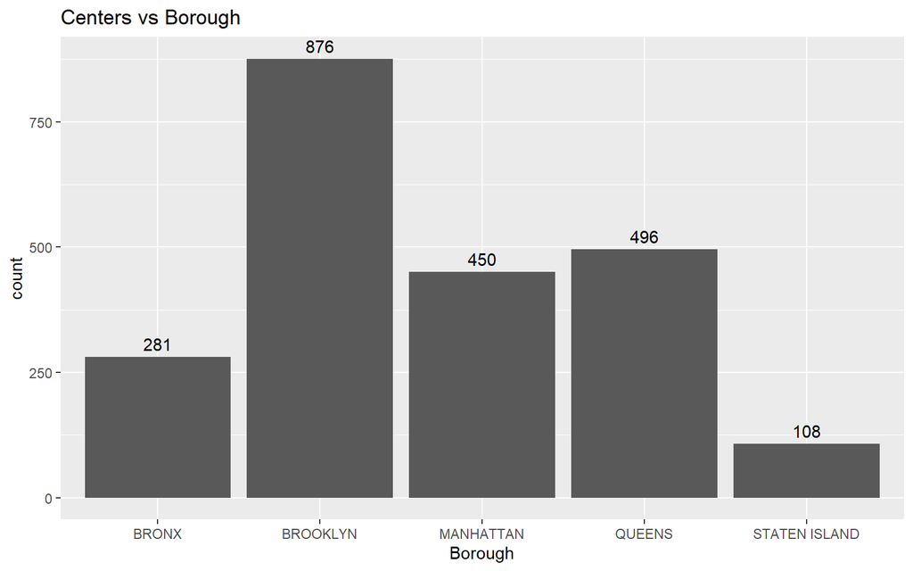

```r
# Discover the distribution of Borough and Program Type across different Institutions
loadPkg("ggplot2")
bar_Bor <- ggplot(Centers, aes(x = Borough)) +
           geom_bar() +
           geom_text(stat = 'count', aes(label = ..count..), vjust = -0.5) +
           ggtitle("Centers vs Borough" )
bar_Bor
```

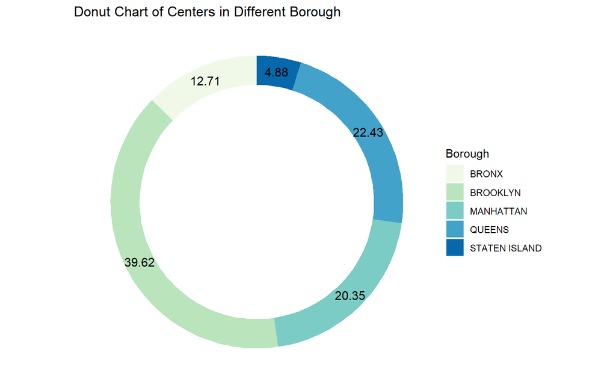

```r
loadPkg("dplyr")
Bor <- group_by(Centers, Borough) %>%
       count() %>%
       ungroup()%>%
       arrange(desc(Borough)) %>%
       mutate(percentage = round(n/sum(n), 4) * 100,
       lab.pos = cumsum(percentage)-.5*percentage,
       ymax = cumsum(percentage),
       ymin = c(0, head(ymax, n = -1)))
donut_Bor <- ggplot(Bor, aes(ymax = ymax, ymin = ymin, xmax = 4, xmin = 3,fill = Borough)) +
             ggtitle("Donut Chart of Centers in Different Borough") +
             geom_rect() +
             geom_text(x = 3.5, aes(y = lab.pos, label = percentage), size = 4) +
             scale_fill_brewer(palette = 4) +
             scale_color_brewer(palette = 4) +
             coord_polar(theta = "y") +
             xlim(c(-1, 4)) +
             theme_void()
donut_Bor
```

From the donut chart above, we can see the distribution of childcare centers in different boroughs. We can see that Brooklyn has the largest number of childcare institutions, occupying 40% in total. Queens and Manhattan run 2nd and 3rd, with around 20% each. Staten Island has the fewest due to population size.

Borough-wise, we can see that Staten Island has the fewest amount of childcare institutions, while Brooklyn has the most. This could be explained by the difference in population across different Boroughs. Manhattan, which is the highest GDP per capita Borough in NY, does not have a large number of childcare centers. This observation could be attributed to demographic and income structure. Manhattan is the Financial and Commercial center, but it is not a residential center, as people tend to live in other parts of the city due to land price. For people who reside in this Borough who are more likely to have higher income to afford the cost of living, they have more alternatives for their children including domestic nurses and tutoring resulting in less demand for childcare centers in this area. This could be contrasted in Brooklyn where the Big Apple’s working class work and live. Here, people are more likely to require a childcare center since they have less alternatives for their children when their parents are not available.

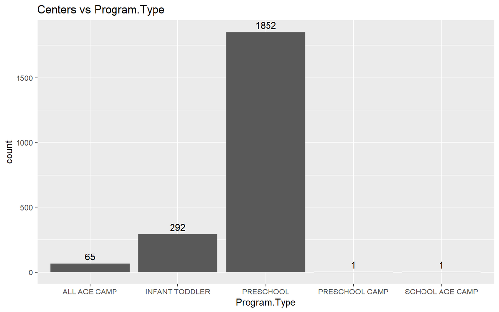

```r
bar_Type <- ggplot(Centers, aes(x = Program.Type)) +
            geom_bar() +
            geom_text(stat = 'count', aes(label = ..count..), vjust = -0.5) +
            ggtitle("Centers vs Program.Type" )
bar_Type
```

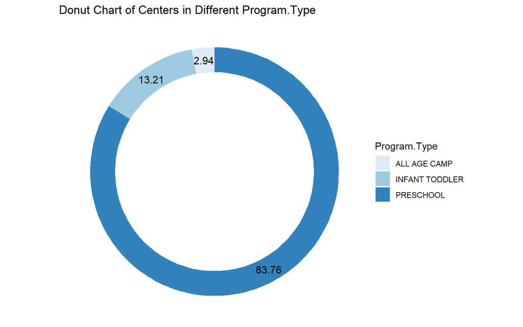

```r
Type <- group_by(Centers, Program.Type) %>%
        count() %>%
        ungroup()%>%
        arrange(desc(Program.Type)) %>%
        mutate(percentage = round(n/sum(n), 4) * 100,
        lab.pos = cumsum(percentage)-.5*percentage,
        ymax = cumsum(percentage),
        ymin = c(0, head(ymax, n = -1)))
Type <- Type[-c(1, 2), ]
donut_Type <- ggplot(Type, aes(ymax = ymax, ymin = ymin, xmax = 4, xmin = 3, fill = Program.Type)) +
              ggtitle("Donut Chart of Centers in Different Program.Type") +
              geom_rect() +
              geom_text(x = 3.5, aes(y = lab.pos, label = percentage), size = 4) +
              scale_fill_brewer(palette = 1) +
              scale_color_brewer(palette = 1) +
              coord_polar(theta = "y") +
              xlim(c(-1, 4)) +
              theme_void()
donut_Type
```

From plot *Centers vs Program.Type*, we can see that there are both one observation in Preschool Camp and School Age Camp. Therefore, we can drop them when we make a donut chart.

From *Donut Chart of Centers in Different Program.Type*, we can see that the majority, more than 80%, of the centers tends to the preschool children, aging between 2 to 5. Infant toddlers from 0 to 2 years old have 13% of the centers. All age camps only occupy 3%. One of the reasons why there are more preschools than infant toddler is that the age span of preschools is relatively large. And for infants, parents are more inclined to raise by themselves or hire a babysitter, but when the child is 2 years old, parents are more willing to let the child go to preschool to learn and get to know more peers.

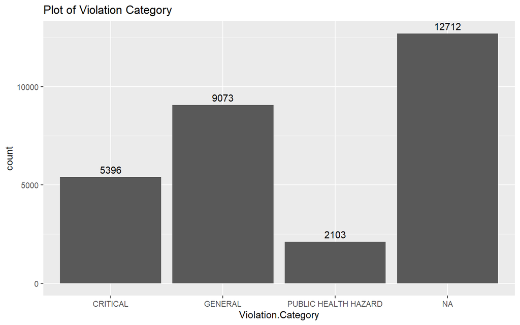

```r
bar_VioCat <- ggplot(childcare, aes(x = Violation.Category)) +
            geom_bar() +
            geom_text(stat = 'count', aes(label = ..count..), vjust = -0.5) +
            ggtitle("Plot of Violation Category")
bar_VioCat
```

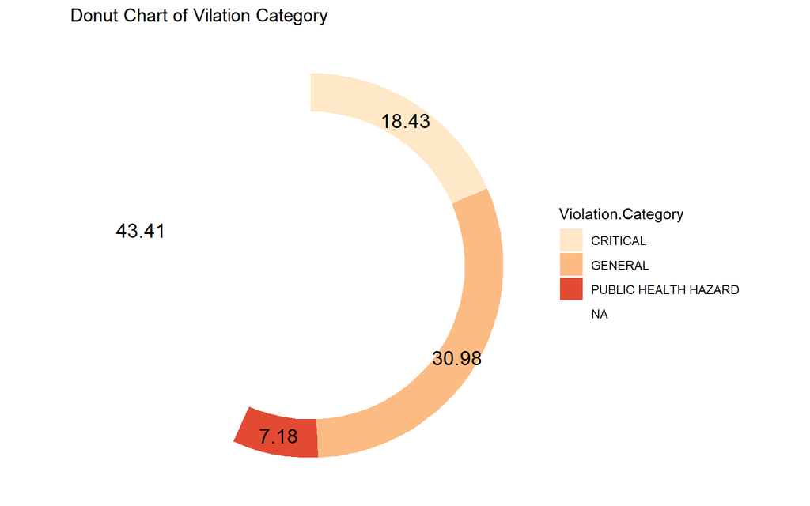

```r
VioCat <- group_by(childcare, Violation.Category) %>%
          count() %>%
          ungroup()%>%
          mutate(percentage = round(n/sum(n), 4) * 100,
          lab.pos = cumsum(percentage)-.5*percentage,
          ymax = cumsum(percentage),
          ymin = c(0, head(ymax, n = -1)))
donut_VioCat <- ggplot(VioCat, aes(ymax = ymax, ymin = ymin, xmax = 4, xmin = 3, fill = Violation.Category)) +
                ggtitle("Donut Chart of Vilation Category") +
                geom_rect() +
                geom_text(x = 3.5, aes(y = lab.pos, label = percentage), size = 5) +
                scale_fill_brewer(palette = 8) +
                scale_color_brewer(palette = 8) +
                coord_polar(theta = "y") +
                xlim(c(-1, 4)) +
                theme_void()
donut_VioCat
```

From *Donut Chart of Violation Category*, 7.18% of all inspections is public health hazard violations, 18.43% is critical Violations, 30.98% is general violations, and 43.41% of all inspections is NA. The NA in violation category means no violation was detected during that inspection. In other words, only around 43.41% of the inspections were violation-free. This also shows that more than half of the violations occurred during this period. It is hoped that through inspections, the subsequent violation rate can be reduced.

### 2.3 Distribution of Total Educational Workers

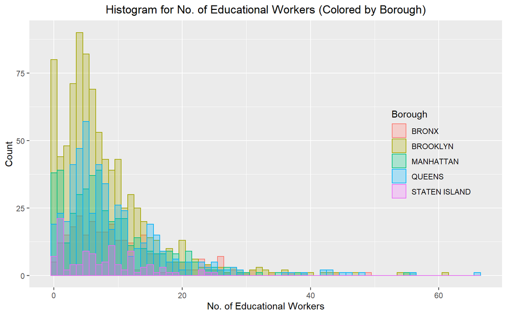

```r
hist_Edu_Bor <- ggplot(Centers, aes(x = Total.Educational.Workers,
                                    color = Borough,
                                    fill = Borough)) +
                geom_histogram(binwidth = 1,
                               alpha = 0.3,
                               position = "identity")+
                theme(plot.title = element_text(hjust = 0.5),
                      legend.background = element_blank(),
                      legend.position = c(0.85, 0.5)) +
                labs(title = "Histogram for No. of Educational Workers (Colored by Borough)",
                     x = "No. of Educational Workers",
                     y = "Count")
hist_Edu_Bor
```

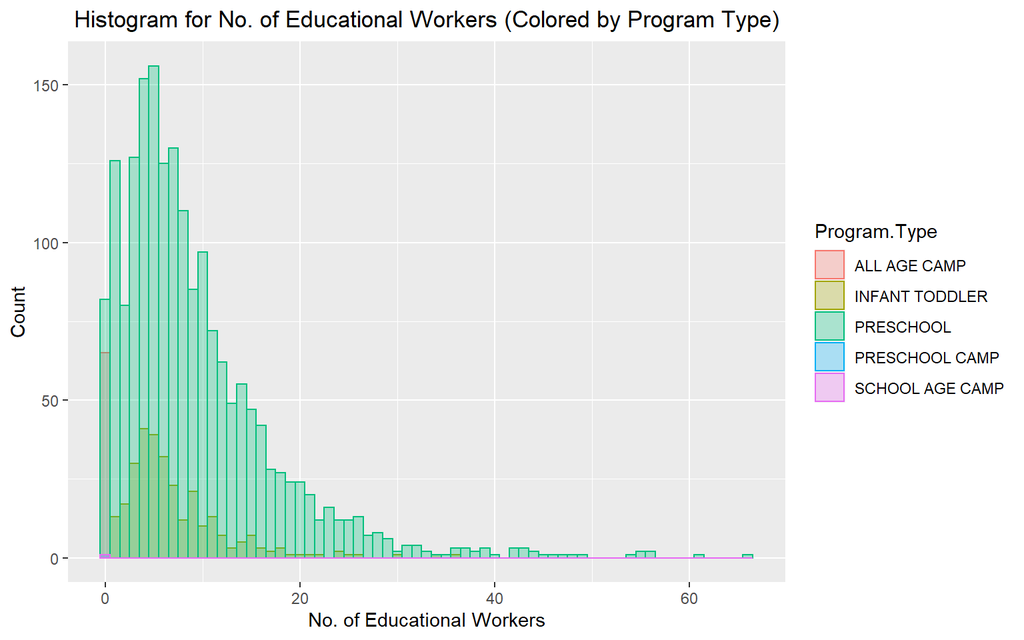

```r
hist_Edu_Typ <- ggplot(Centers, aes(x = Total.Educational.Workers,
                                    color = Program.Type,
                                    fill = Program.Type)) +
                geom_histogram(binwidth = 1,
                               alpha = 0.3,
                               position = "identity")+
                theme(plot.title = element_text(hjust = 0.5)) +
                labs(title = "Histogram for No. of Educational Workers (Colored by Program Type)",
                     x = "No. of Educational Workers",
                     y = "Count")
hist_Edu_Typ
```

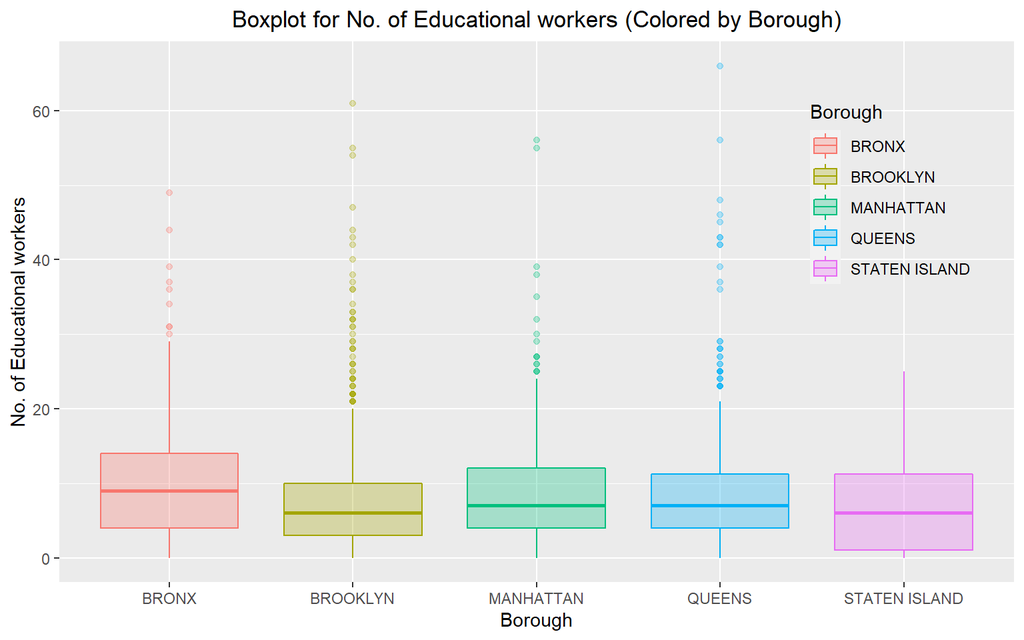

```r
box_Edu_Bor <- ggplot(Centers, aes(y = Total.Educational.Workers,
                                   x = Borough,
                                   fill = Borough,
                                   color = Borough)) +
               geom_boxplot(alpha = 0.3) +
               theme(plot.title = element_text(hjust = 0.5),
                      legend.background = element_blank(),
                      legend.position = c(0.87, 0.72)) +
               ggtitle("Boxplot for No. of Educational workers (Colored by Borough)") +
               scale_y_continuous(name = "No. of Educational workers") +
               scale_x_discrete(name = "Borough")
box_Edu_Bor
```

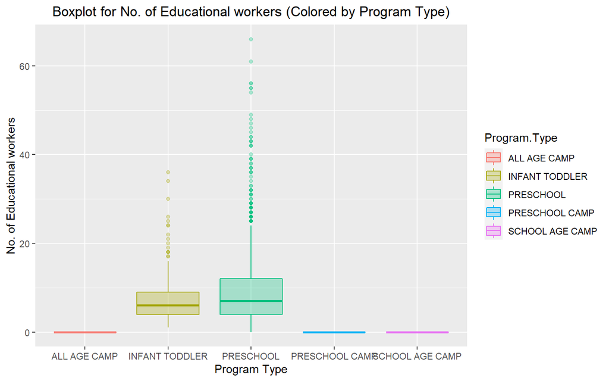

```r
box_Edu_Typ <- ggplot(Centers, aes(y = Total.Educational.Workers,
                                   x = Program.Type,
                                   fill = Program.Type,
                                   color = Program.Type)) +
               geom_boxplot(alpha = 0.3) +
               theme(plot.title = element_text(hjust = 0.5)) +
               ggtitle("Boxplot for No. of Educational workers (Colored by Program Type)") +
               scale_y_continuous(name = "No. of Educational workers") +
               scale_x_discrete(name = "Program Type")
box_Edu_Typ
```

```r
median(Centers$Total.Educational.Workers)
quantile(Centers$Total.Educational.Workers, 0.8)
```

[output not shown]

We could have a glimpse of the intrinsic nature of these centers. From the number of educational workers and their maximum capacity to host children, we can better understand this dataset. We can see from this histogram plotted with binwidth=1, the distribution of educational workers is heavily right skewed. The majority of the institutions cluster around the smaller side, with a median of 7 workers and 80% quantile 13 workers; while the long tail, outliers continue to pop up. This pattern does not differ from Borough to Borough.

### 2.4 Distribution of Maximum Capacity

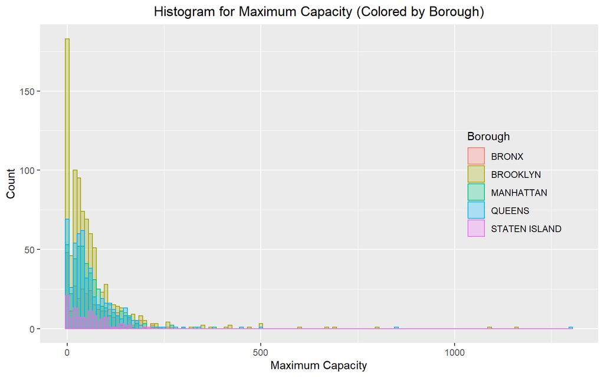

```r
hist_Cap_Bor <- ggplot(Centers, aes(x = Maximum.Capacity,
                                    color = Borough,
                                    fill = Borough)) +
                geom_histogram(binwidth = 10,
                               alpha = 0.3,
                               position = "identity")+
                theme(plot.title = element_text(hjust = 0.5),
                      legend.background = element_blank(),
                      legend.position = c(0.85, 0.5)) +
                labs(title = "Histogram for Maximum Capacity (Colored by Borough)",
                     x = "Maximum Capacity",
                     y = "Count")
hist_Cap_Bor
```

The maximum capacity distribution is even more skewed, from the histogram with binwidth=10 plotted here, the median of the max capacity is 41 children and the 80% quantile is 94, displaying the same pattern with long tail.

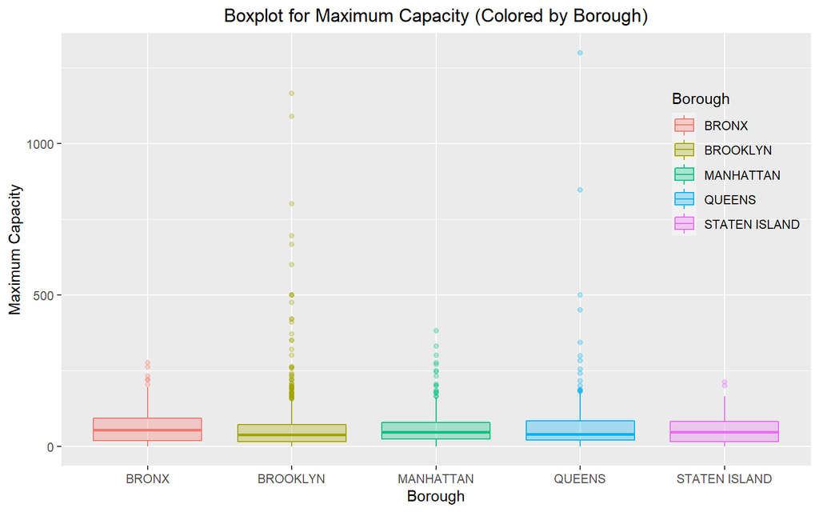

```r
box_Cap_Bor <- ggplot(Centers, aes(y = Maximum.Capacity,
                                   x = Borough,
                                   fill = Borough,
                                   color = Borough)) +
               geom_boxplot(alpha = 0.3) +
               theme(plot.title = element_text(hjust = 0.5),
                      legend.background = element_blank(),
                      legend.position = c(0.9, 0.7)) +
               ggtitle("Boxplot for Maximum Capacity (Colored by Borough)") +
               scale_y_continuous(name = "Maximum Capacity") +
               scale_x_discrete(name = "Borough")
box_Cap_Bor
```

```r
median(Centers$Maximum.Capacity)
quantile(Centers$Maximum.Capacity, 0.8)
```

[output not shown]

From above plots, we can portray the big picture for childcare industry: the largest bulk consists of small care units with 15 educational workers or less, tending less than 100 children maximum. These institutions serve their local community, but like the nature of education facilities, different needs always need to be tailored and catered. Larger institutions with more workers that can take care of more children always persists, making the entire distribution long-tailed.

## 3 Statistical Testing

### 3.1 Preparation for cor.test

```r
child2<-childcare[c("Inspection.Date","Violation.Rate.Percent","Borough")]
child2 <- na.omit(child2)
str(child2)
```

```
## 'data.frame':    29134 obs. of  3 variables:
##  $ Inspection.Date       : chr  "03/13/2018" "06/25/2018" "01/29/2020" "10/08/2019" ...
##  $ Violation.Rate.Percent: num  66.7 25 0 66.7 16.7 ...
##  $ Borough               : chr  "BRONX" "QUEENS" "STATEN ISLAND" "BRONX" ...
##  - attr(*, "na.action")= 'omit' Named int [1:150] 129 955 1147 1355 1467 1695 1872 1900 2137 2164 ...
##   ..- attr(*, "names")= chr [1:150] "158" "1174" "1446" "1685" ...
```

We will use cor.test to figure out Which borough has improved over the period (2018-2021). So, we deleted NA values and some unuseful variables which are unrelated to the question. We only need 3 variables such as Inspection.Date, Violation.Rate,Percent and Borough. There are 29134 observations and 3 variables in this dataset which we called *child2*.

```r
child2$Inspection.Date<-substring(child2$Inspection.Date,nchar(as.character(child2$Inspection.Date))-3)
```

```r
loadPkg("dplyr")
d1<-child2 %>% group_by(Borough,Inspection.Date)%>% mutate(Violation.Rate.Percent=mean(Violation.Rate.Percent))
# unique(d1)
d1 <- unique(d1)
xkabledply(d1, title = "Table: d1")
```

Table: d1

| Inspection.Date | Violation.Rate.Percent | Borough |
| --- | --- | --- |
| 2018 | 54.7 | BRONX |
| 2018 | 43.2 | QUEENS |
| 2020 | 16.3 | STATEN ISLAND |
| 2019 | 53.4 | BRONX |
| 2018 | 30.4 | BROOKLYN |
| 2019 | 27.6 | MANHATTAN |
| 2018 | 27.6 | MANHATTAN |
| 2020 | 27.1 | BROOKLYN |
| 2019 | 30.6 | BROOKLYN |
| 2020 | 35.4 | QUEENS |
| 2020 | 54.9 | BRONX |
| 2021 | 18.5 | STATEN ISLAND |
| 2018 | 17.9 | STATEN ISLAND |
| 2021 | 31.0 | BROOKLYN |
| 2021 | 54.3 | BRONX |
| 2020 | 25.8 | MANHATTAN |
| 2019 | 39.4 | QUEENS |
| 2021 | 23.9 | MANHATTAN |
| 2019 | 18.0 | STATEN ISLAND |
| 2021 | 28.2 | QUEENS |

In child2, we have the violation rate for everyday in each Borough which we then took the average of the violation rates and created dataset *d1*. The *d1* contains the average violation rate for every year in each Borough.

```r
d1$Inspection.Date<-as.numeric(d1$Inspection.Date)
d1$Violation.Rate.Percent<-as.numeric(d1$Violation.Rate.Percent)
d1brokk<-subset(d1,Borough=="BROOKLYN")
d1bqn<-subset(d1,Borough=="QUEENS")
d1st<-subset(d1,Borough=="STATEN ISLAND")
d1mn<-subset(d1,Borough=="MANHATTAN")
d1brons<-subset(d1,Borough=="BRONX")
xkabledply(d1brokk, title = "Table: Brooklyn")
```

Table: Brooklyn

| Inspection.Date | Violation.Rate.Percent | Borough |
| --- | --- | --- |
| 2018 | 30.4 | BROOKLYN |
| 2020 | 27.1 | BROOKLYN |
| 2019 | 30.6 | BROOKLYN |
| 2021 | 31.0 | BROOKLYN |

```r
xkabledply(d1bqn, title = "Table: Queens")
```

Table: Queens

| Inspection.Date | Violation.Rate.Percent | Borough |
| --- | --- | --- |
| 2018 | 43.2 | QUEENS |
| 2020 | 35.4 | QUEENS |
| 2019 | 39.4 | QUEENS |
| 2021 | 28.2 | QUEENS |

```r
xkabledply(d1st, title = "Table: Staten Island")
```

Table: Staten Island

| Inspection.Date | Violation.Rate.Percent | Borough |
| --- | --- | --- |
| 2020 | 16.3 | STATEN ISLAND |
| 2021 | 18.5 | STATEN ISLAND |
| 2018 | 17.9 | STATEN ISLAND |
| 2019 | 18.0 | STATEN ISLAND |

```r
xkabledply(d1mn, title = "Table: Manhattan")
```

Table: Manhattan

| Inspection.Date | Violation.Rate.Percent | Borough |
| --- | --- | --- |
| 2019 | 27.6 | MANHATTAN |
| 2018 | 27.6 | MANHATTAN |
| 2020 | 25.8 | MANHATTAN |
| 2021 | 23.9 | MANHATTAN |

```r
xkabledply(d1brons, title = "Table: Bronx")
```

Table: Bronx

| Inspection.Date | Violation.Rate.Percent | Borough |
| --- | --- | --- |
| 2018 | 54.7 | BRONX |
| 2019 | 53.4 | BRONX |
| 2020 | 54.9 | BRONX |
| 2021 | 54.3 | BRONX |

We wanted to study the changes in violation rates in 5 different boroughs, so we divide them into 5 subsets, namely Brooklyn, Queens, Staten Island, Manhattan, and Bronx. Then, we used cor.test to study the correlation between inspection date and violation rate in five boroughs.

### 3.2 Cor.test

```r
c1<-cor.test(d1brokk$Inspection.Date,d1brokk$Violation.Rate.Percent, na.action = na.omit)
c1
```

```
##
##  Pearson's product-moment correlation
##
## data:  d1brokk$Inspection.Date and d1brokk$Violation.Rate.Percent
## t = -0.1, df = 2, p-value = 0.9
## alternative hypothesis: true correlation is not equal to 0
## 95 percent confidence interval:
##  -0.968  0.952
## sample estimates:
##    cor
## -0.105
```

```r
c2<-cor.test(d1bqn$Inspection.Date,d1bqn$Violation.Rate.Percent, na.action = na.omit)
c2
```

```
##
##  Pearson's product-moment correlation
##
## data:  d1bqn$Inspection.Date and d1bqn$Violation.Rate.Percent
## t = -8, df = 2, p-value = 0.01
## alternative hypothesis: true correlation is not equal to 0
## 95 percent confidence interval:
##  -1.000 -0.472
## sample estimates:
##    cor
## -0.986
```

```r
c3<-cor.test(d1st$Inspection.Date,d1st$Violation.Rate.Percent, na.action = na.omit)
c3
```

```
##
##  Pearson's product-moment correlation
##
## data:  d1st$Inspection.Date and d1st$Violation.Rate.Percent
## t = 0.03, df = 2, p-value = 1
## alternative hypothesis: true correlation is not equal to 0
## 95 percent confidence interval:
##  -0.960  0.963
## sample estimates:
##    cor
## 0.0196
```

```r
c4<-cor.test(d1mn$Inspection.Date,d1mn$Violation.Rate.Percent, na.action = na.omit)
c4
```

```
##
##  Pearson's product-moment correlation
##
## data:  d1mn$Inspection.Date and d1mn$Violation.Rate.Percent
## t = -4, df = 2, p-value = 0.05
## alternative hypothesis: true correlation is not equal to 0
## 95 percent confidence interval:
##  -0.999  0.141
## sample estimates:
##    cor
## -0.949
```

```r
c5<-cor.test(d1brons$Inspection.Date,d1brons$Violation.Rate.Percent, na.action = na.omit)
c5
```

```
##
##  Pearson's product-moment correlation
##
## data:  d1brons$Inspection.Date and d1brons$Violation.Rate.Percent
## t = 0.07, df = 2, p-value = 0.9
## alternative hypothesis: true correlation is not equal to 0
## 95 percent confidence interval:
##  -0.957  0.965
## sample estimates:
##   cor
## 0.051
```

### 3.3 Violation Rate percent vs. Inspection date across Borough

```r
# install.packages("ggthemes") Install
library(ggthemes)
```

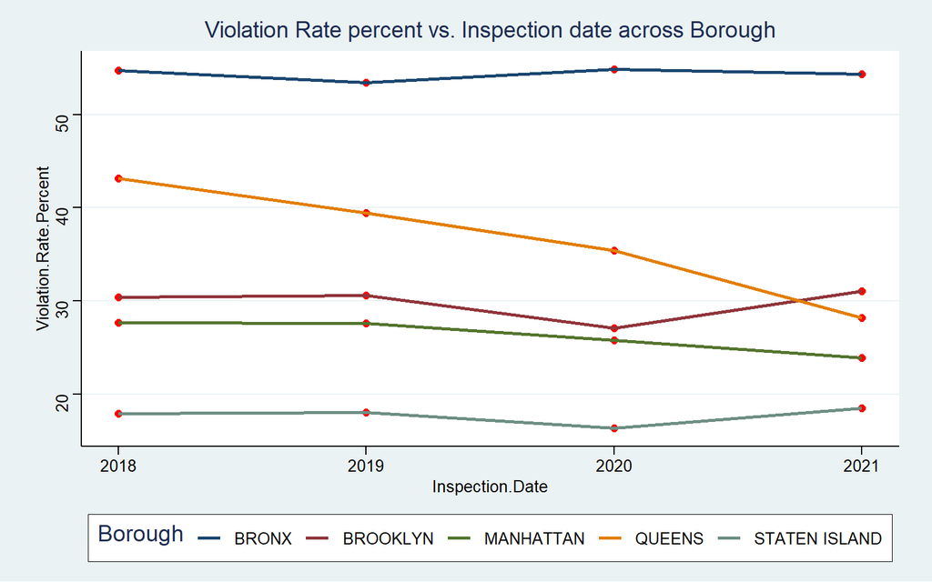

```r
loadPkg("ggplot2")
ggplot(d1,aes(x=Inspection.Date,y=Violation.Rate.Percent,group=Borough,color=Borough))+geom_point(size=2,color='red')+geom_line(size=1)+ggtitle("Violation Rate percent vs. Inspection date across Borough")+theme_stata() + scale_color_stata()
```

## 4 Model Building

### 4.1 Correlation Matrix

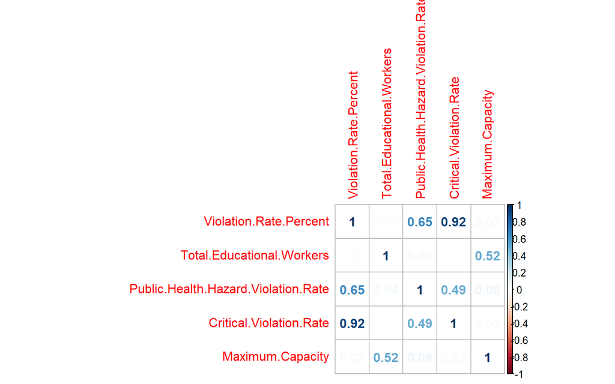

```r
library(corrplot)
violation = childcare %>% subset(select = c(Violation.Rate.Percent, Total.Educational.Workers, Public.Health.Hazard.Violation.Rate, Critical.Violation.Rate, Maximum.Capacity))
corr_violation = cor(violation, use = "complete.obs")
corrplot(corr_violation, method = 'number')
```

We only look for the correlation of numeric variables in *childcare* dataset, so we use the numeric variables information in this dataset to get the above correlation matrix. We can see there is a strong correlation between Violation.Rate.Percent and Critical.Violation.Rate. And there is a moderate correlation between Violation.Rate.Percent and Public.Health.Hazard.Violation.Rate, Public.Health.Hazard.Violation.Rate and Critical.Violation.Rate and Maximum.Capacity and Total.Educational.Workers.

### 4.2 Generalized Linear Model

```r
#Step 5 - Generalized linear model for predicting if inspection will lead to a violation being cited or not
loadPkg("dplyr")
# Remove unnecessary columns and create column called Violation.Flag to show if inspection has resulted in a violation or not
glm_childcare <- childcare %>% subset(select = -c(Date.Permitted))
glm_childcare = glm_childcare %>% mutate(Violation.Flag = ifelse(is.na(Violation.Category), 0, 1))
# Remove/replace NAs with desired values in each column
glm_childcare$Violation.Category[is.na(glm_childcare$Violation.Category)] <- 'NO VIOLATION'
glm_childcare$Violation.Rate.Percent[is.na(glm_childcare$Violation.Rate.Percent)] <- 0
glm_childcare$Average.Violation.Rate.Percent[is.na(glm_childcare$Average.Violation.Rate.Percent)] <- 0
glm_childcare$Public.Health.Hazard.Violation.Rate[is.na(glm_childcare$Public.Health.Hazard.Violation.Rate)] <- 0
glm_childcare$Average.Public.Health.Hazard.Violation.Rate[is.na(glm_childcare$Average.Public.Health.Hazard.Violation.Rate)] <- 0
glm_childcare$Violation.Rate.Percent[is.na(glm_childcare$Violation.Rate.Percent)] <- 0
glm_childcare$Average.Violation.Rate.Percent[is.na(glm_childcare$Average.Violation.Rate.Percent)] <- 0
glm_childcare$Critical.Violation.Rate[is.na(glm_childcare$Critical.Violation.Rate)] <- 0
glm_childcare$Average.Critical.Violation.Rate[is.na(glm_childcare$Average.Critical.Violation.Rate)] <- 0
glm_childcare <- glm_childcare %>% filter(!is.na(Inspection.Date))
# Check if dataset has any NA values
sapply(glm_childcare,function(x) sum(is.na(x)))
# Convert categorical variables to required datatype
glm_childcare$Program.Type <- as.factor(glm_childcare$Program.Type)
glm_childcare$Borough <- as.factor(glm_childcare$Borough)
glm_childcare$Status <- as.factor(glm_childcare$Status)
glm_childcare$Program.Type <- as.factor(glm_childcare$Program.Type)
glm_childcare$Facility.Type <- as.factor(glm_childcare$Facility.Type)
glm_childcare$Child.Care.Type <- as.factor(glm_childcare$Child.Care.Type)
glm_childcare$Violation.Category <- as.factor(glm_childcare$Violation.Category)
glm_childcare$Violation.Status <- as.factor(glm_childcare$Violation.Status)
glm_childcare$Violation.Flag <- as.factor(glm_childcare$Violation.Flag)
# Randomize test and train datasets (90:10)
glm_childcare
library(caTools)
set.seed(1000)
sample = sample.split(glm_childcare, SplitRatio = .90)
train = subset(glm_childcare, sample == TRUE)
test  = subset(glm_childcare, sample == FALSE)
```

```r
# GLM model training
model <- glm(Violation.Flag ~ Public.Health.Hazard.Violation.Rate + Critical.Violation.Rate + Borough, family=binomial, data=train)
# summary(model)
xkabledply(model)
```

Table

|  | Estimate | Std. Error | z value | Pr(>\|z\|) |
| --- | --- | --- | --- | --- |
| (Intercept) | -0.2758 | 0.0394 | -7.000 | 0.0000 |
| Public.Health.Hazard.Violation.Rate | 0.0116 | 0.0008 | 14.805 | 0.0000 |
| Critical.Violation.Rate | 0.0180 | 0.0006 | 30.110 | 0.0000 |
| BoroughBROOKLYN | -0.3153 | 0.0401 | -7.870 | 0.0000 |
| BoroughMANHATTAN | -0.0307 | 0.0436 | -0.704 | 0.4813 |
| BoroughQUEENS | -0.2388 | 0.0420 | -5.690 | 0.0000 |
| BoroughSTATEN ISLAND | -0.2589 | 0.0740 | -3.498 | 0.0005 |

In above model, the *Public.Health.Hazard.Violation*, *Critical.Violation.Rate*, *BoroughBROOKLYN*, *BoroughQUEENS* and *BoroughSTATEN ISLAND* are statistically significant because their p-value are less than 0.05. And the *BoroughMANHATTAN* is not statistically significant because its p-value are greater than 0.05.

```r
# VIF check for collinearity (Remove multicollinear factors eg: Violation.Rate.Percent has a strong positive correlation with Critical.Violation.Rate.Percent)
xkablevif(model)
```

VIFs of the model

| BoroughBROOKLYN | BoroughMANHATTAN | BoroughQUEENS | BoroughSTATEN ISLAND | Critical.Violation.Rate | Public.Health.Hazard.Violation.Rate |
| --- | --- | --- | --- | --- | --- |
| 7.41 | 7.12 | 8.63 | 7.95 | 7.68 | 5.16 |

In the model, the output above shows that the VIF value for all variables exceed 5, so there is high multicollinearity among these factors.

## 6 Bibliography

Data Source: https://data.cityofnewyork.us/Health/DOHMH-Childcare-Center-Inspections/dsg6-ifza